# XAJ_modelling

Xiaoxiang Guan

2023-10-09

## Introduction

This is a brief tutorial on how to implement the source code for hydrological modelling, by using Xinanjiang (XAJ) model.

First, load the `XAJ.R` source code into the console (R session), together with the `rtop` library in order to use the SCE-UA algorithm for model calibration.

```r
library(rtop)
ws <- "D:/HydroModel/"
source(paste0(ws, "scr/XAJ.R"))
```

## Import the example data

import the example data `data/DATA_Area4766_1982-2002.csv`. This example data set covers the basic variables needed for modelling: precipitation (mm), potential evapotranspiration (mm) and discharge (m3/s) all at the daily step. The dataset covers the observation period of 1982-2002. The example catchment has an area of 4766 km2.

```r
dat = read.table(paste0(ws, "data/DATA_Area4766_1982-2002.csv"),header = T,sep = ",")

P = dat[,4]
E = dat[,5]
Q = dat[,6]
DAREA = 4766 ##
DT = 24
head(dat, 8)
```

```
##      y m d    p   e        q
## 1 1982 1 1 0.00 1.3 38.33985
## 2 1982 1 2 0.00 0.6 37.77818
## 3 1982 1 3 1.59 0.6 37.98347
## 4 1982 1 4 1.44 0.5 39.98868
## 5 1982 1 5 0.00 0.9 38.73206
## 6 1982 1 6 0.00 0.8 35.57731
## 7 1982 1 7 0.00 1.6 34.09355
## 8 1982 1 8 0.00 1.1 32.89951
```

## XAJ model calibration based on SCE-UA algorithm

create the global variables in order to make the data available for the calibration (fitting) function during mutiple iteration processes.

```r
#-----定义全局变量 (define global variables)-----
Validinput_P <<- P
Validinput_E <<- E
Validinput_Q <<- Q
Validinput_DAREA <<- DAREA  ## catchment area in km2
Validinput_DT <<- 24  ## simulation time step
```

there are 15 parameters in XAJ we defined to be calibrated. For the description on the parameters, refer to the documents.

```r
#-------------1    2    3     4    5     6     7    8     9    10   11   12   13   14  15
#-------------Kc, SM,   B,    C   Ex   WUM   WLM  WDM    Kg    Ki   Cs   Ci   Cg   CR  L
paralower = c(0.1,5  ,  0.1, 0.05, 1.0,  40,  20,  5, 0.25, 0.25, 0.1, 0.8, 0.8, 0.1, 0)
paraupper = c(1  ,50 ,  1.5,  0.2, 1.4, 300, 150, 60, 0.49, 0.49,   6,   1,   1, 0.6, 3)
parainitial=c(0.6,20 ,  0.4,  0.1, 1.2, 180,  40, 10,  0.3,  0.4, 0.4, 0.9, 0.9, 0.3, 0)
fit = function(x) {
  Kc = x[1]; SM = x[2];WUM = x[6];WLM = x[7];WDM = x[9];
  B = x[3];C = x[4];Ex = x[5];Kg = x[9];Ki = x[10];
  Cs = x[11];Ci = x[12];Cg = x[13];CR = x[14];L = x[15]
  out = XAJ(Validinput_P, Validinput_E, Validinput_Q, Validinput_DAREA, Validinput_DT,
            Kc, SM, B, C,Ex,WUM, WLM, WDM,
            Kg, Ki,
            Cg, Cs, Ci, CR,L)
  Qsi = out
  Qre = Validinput_Q
  R2 = 1-sum((Qre-Qsi)^2,na.rm = T)/sum((Qre-mean(Qre))^2,na.rm = T) #NSE
  return(1-R2)
}
```

calibrate the XAJ model by using the `sceua()` from R package `rtop`. The calibrated parameters (results) could be used to rerun the model to check the performance of model.

```r
sceua_xaj = sceua(fit, pars = parainitial, lower = paralower,
                  upper = paraupper, maxn = 1000, pcento = 0.00001, iprint = 0)
```

```
## 310 best 0.279 function convergence 2e+05 parameter convergence 9788.523
## 482 best 0.153 function convergence 2e+05 parameter convergence 9524.928
## 687 best 0.142 function convergence 2e+05 parameter convergence 8840.462
## 882 best 0.113 function convergence 2e+05 parameter convergence 7874.032
## 1086 best 0.103 function convergence 2e+05 parameter convergence 6926.345
```

```r
x = sceua_xaj$par
print(x)
```

```
##  [1]  0.4213451 48.8652396  1.1752139  0.1617429  1.2192133 86.8459894
##  [7] 95.3872213 30.3224994  0.4637969  0.2849933  0.5068855  0.8940921
## [13]  0.9974578  0.1446365  0.3819332
```

```r
Kc = x[1]; SM = x[2];WUM = x[6];WLM = x[7];WDM = x[9];
B = x[3];C = x[4];Ex = x[5];Kg = x[9];Ki = x[10];
Cs = x[11];Ci = x[12];Cg = x[13];CR = x[14];L = x[15]
out = XAJ(Validinput_P, Validinput_E, Validinput_Q, Validinput_DAREA, Validinput_DT,
          Kc, SM, B, C,Ex,WUM, WLM, WDM,
          Kg, Ki,
          Cg, Cs, Ci, CR,L)
Qsi = out
Qre = Validinput_Q
R2 = 1-sum((Qre-Qsi)^2,na.rm = T)/sum((Qre-mean(Qre))^2,na.rm = T) #NSE
print(paste0("NSE: ", round(R2, 4)))
```

```
## [1] "NSE: 0.8966"
```

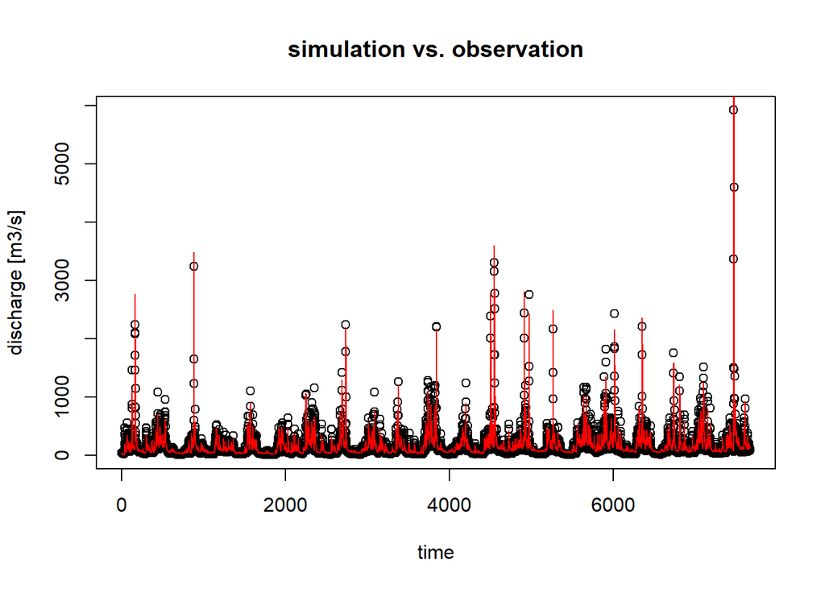

```r
#--- obs VS. sim
plot(1:length(Validinput_Q),Validinput_Q,
     xlab = "time", ylab = "discharge [m3/s]", main = "simulation vs. observation")
points(1:length(Qsi),Qsi, type = "l",col = "red")
```

here we plot the observed and simulated discharge processes in the same plot (observation: black points, and simulation: red line), with an attempt to have a straightforward understanding how well the XAJ simulates the discharge processes. The result displays that the XAJ model performs well in discharge simulation for the example catchment, under the support the SCE-UA algorithm. The main conclusion could be the XAJ model together with the parameter calibration algorithm shows a good performance and have a positive application potential.